# DT v3: Copan Forehead subset으로 decontam 이해하기

DT Swab project

2026-09-18

# 1 분석 목적

이 문서는 전처리된 DT phyloseq v3 객체에서 다음 6개 샘플만 골라 `decontam`의 frequency 방법과 prevalence 방법을 비교한다.

- True sample: Copan swab으로 채취한 Forehead 샘플 5개
- Negative control: Copan swab에 해당하는 음성대조군 1개

> **입력 자료 범위:** HV pre-decontam phyloseq 객체는 control 3개와 Forehead 17개를 포함하지만, sample metadata에 `swab_type`과 DNA 농도가 없다. 따라서 HV 분석 구조를 참고하되, `Copan Forehead 5 + Copan control 1`과 frequency 분석을 재현할 수 있는 실제 입력인 DT v3 객체와 QC 농도 metadata를 이 튜토리얼에 사용한다.

이 작은 subset은 알고리즘과 threshold의 의미를 확인하기 위한 교육용 예시이다. 특히 prevalence 방법은 음성대조군이 한 개뿐이어서 검정력이 매우 제한된다. Frequency 방법도 DNA 농도 범위가 좁으면 안정적인 구분이 어렵다. 따라서 여기서 얻은 분류를 전체 자료의 최종 오염 제거 규칙으로 바로 사용하지 않는다.

`decontam`의 `p`는 **오염 비율**이나 **오염일 확률**이 아니다. Frequency에서는 농도와 무관한 모형보다 오염원에 특징적인 역상관 모형이 더 잘 맞는지, Prevalence에서는 True sample보다 control에 더 자주 나타나는지를 평가하여 만든 방법별 score이다. `p < threshold`인 feature를 contaminant로 분류한다. 따라서 threshold를 높일수록 분류 기준이 완화되어 더 많은 feature가 contaminant가 된다.

# 2 1. 입력 자료와 sample subset

## 2.1 1.1 phyloseq v3 불러오기

```r
phy_v3 <- readRDS("Phyloseq/phy_F270R240_260812_v3.rds")

sample_metadata <- data.frame(
  sample_data(phy_v3),
  check.names = FALSE
) %>%
  rownames_to_column("phyloseq_sample_id")

sample_metadata %>%
  count(swab_type, site_group, control_status, .drop = FALSE) %>%
  kable(caption = "v3 sample metadata 구성")
```

v3 sample metadata 구성

| swab_type | site_group | control_status | n |
| --- | --- | --- | --- |
| Copan | Antecubital | sample | 5 |
| Copan | Forehead | sample | 5 |
| Copan | negative-control | NA | 1 |
| Eswab | Antecubital | sample | 5 |
| Eswab | Forehead | sample | 5 |
| Eswab | negative-control | NA | 1 |
| Omni | Antecubital | sample | 5 |
| Omni | Forehead | sample | 5 |
| Omni | negative-control | NA | 1 |
| Puritan | Antecubital | sample | 10 |
| Puritan | Forehead | sample | 10 |
| Puritan | negative-control | NA | 2 |

## 2.2 1.2 Copan Forehead 5개와 Copan control 1개 선택

`control_status == "sample"`인 Forehead-Copan 행을 True sample로 두고, `site_group == "negative-control"`이면서 `swab_type == "Copan"`인 행을 control로 선택한다.

```r
selected_metadata <- sample_metadata %>%
  filter(
    swab_type == "Copan",
    (site_group == "Forehead" & control_status == "sample") |
      site_group == "negative-control"
  ) %>%
  mutate(
    is_control = site_group == "negative-control",
    sample_class = if_else(is_control, "Negative control", "True sample")
  )

phy_copan_forehead <- prune_samples(
  selected_metadata$phyloseq_sample_id,
  phy_v3
)

phy_copan_forehead <- prune_taxa(
  taxa_sums(phy_copan_forehead) > 0,
  phy_copan_forehead
)

selected_metadata <- selected_metadata %>%
  mutate(
    read_depth = as.numeric(
      sample_sums(phy_copan_forehead)[phyloseq_sample_id]
    )
  )

selected_metadata %>%
  select(
    phyloseq_sample_id,
    subject_id,
    swab_type,
    site_group,
    sample_class,
    read_depth
  ) %>%
  arrange(sample_class, subject_id) %>%
  kable(
    caption = "decontam 예제에 포함된 6개 샘플",
    format.args = list(big.mark = ",")
  )
```

decontam 예제에 포함된 6개 샘플

| phyloseq_sample_id | subject_id | swab_type | site_group | sample_class | read_depth |
| --- | --- | --- | --- | --- | --- |
| 001NCXUSw | Control | Copan | negative-control | Negative control | 21,949 |
| 001FhRUSw_1 | S001 | Copan | Forehead | True sample | 31,711 |
| 002FhRUSw_1 | S002 | Copan | Forehead | True sample | 12,350 |
| 003FhRUSw_1 | S003 | Copan | Forehead | True sample | 11,048 |
| 004FhRUSw_1 | S004 | Copan | Forehead | True sample | 18,119 |
| 005FhRUSw_1 | S005 | Copan | Forehead | True sample | 24,068 |

Subset 결과는 **6개 sample**, **386개 관찰 feature**이다. 전체 v3 객체에서 이 6개 샘플에 한 번도 나타나지 않은 feature는 `prune_taxa()`로 제외했다.

## 2.3 1.3 Frequency 분석용 DNA 농도 결합

Frequency 방법은 sequencing 이전의 양성 DNA 농도가 필요하다. 기존 QC metadata의 `Original_QC_Conc_ng_uL`을 sample ID로 결합한다.

```r
concentration_metadata <- read.csv(
  "examples/decontam_realdata_check/input/concentration_metadata.csv",
  stringsAsFactors = FALSE,
  check.names = FALSE
) %>%
  as_tibble()

selected_metadata <- selected_metadata %>%
  left_join(
    concentration_metadata %>%
      select(
        Sample_Name,
        Original_QC_Conc_ng_uL,
        Library_QC_Conc_ng_uL
      ),
    by = c("phyloseq_sample_id" = "Sample_Name")
  ) %>%
  arrange(match(phyloseq_sample_id, sample_names(phy_copan_forehead)))

metadata_for_phyloseq <- selected_metadata %>%
  select(-phyloseq_sample_id) %>%
  as.data.frame()

rownames(metadata_for_phyloseq) <- selected_metadata$phyloseq_sample_id
sample_data(phy_copan_forehead) <- sample_data(metadata_for_phyloseq)

selected_metadata %>%
  select(
    phyloseq_sample_id,
    sample_class,
    Original_QC_Conc_ng_uL,
    Library_QC_Conc_ng_uL,
    read_depth
  ) %>%
  kable(
    caption = "선택 샘플의 DNA 농도와 read depth",
    digits = 2,
    format.args = list(big.mark = ",")
  )
```

선택 샘플의 DNA 농도와 read depth

| phyloseq_sample_id | sample_class | Original_QC_Conc_ng_uL | Library_QC_Conc_ng_uL | read_depth |
| --- | --- | --- | --- | --- |
| 001FhRUSw_1 | True sample | 0.50 | 13.20 | 31,711 |
| 001NCXUSw | Negative control | 0.43 | 4.54 | 21,949 |
| 002FhRUSw_1 | True sample | 0.50 | 15.60 | 12,350 |
| 003FhRUSw_1 | True sample | 0.47 | 7.62 | 11,048 |
| 004FhRUSw_1 | True sample | 0.46 | 7.03 | 18,119 |
| 005FhRUSw_1 | True sample | 0.42 | 3.90 | 24,068 |

이 분석에 사용한 원시 DNA 농도 범위는 0.42–0.50 ng/µL이다. 범위가 좁으므로 frequency score의 분리 능력도 제한될 수 있다.

# 3 2. decontam 분석

두 방법 모두 같은 phyloseq subset을 직접 입력한다. `normalize = TRUE`이므로 sample별 feature count를 합이 1인 frequency로 변환한 뒤 계산한다.

- **Frequency:** feature의 상대빈도가 DNA 농도와 역관계를 보이는지 평가
- **Prevalence:** feature가 True sample보다 negative control에서 더 자주 검출되는지 평가

```r
dna_concentration <- sample_data(phy_copan_forehead)$Original_QC_Conc_ng_uL %>%
  as.numeric()

negative_control <- sample_data(phy_copan_forehead)$is_control %>%
  as.logical()

frequency_result <- isContaminant(
  phy_copan_forehead,
  method = "frequency",
  conc = dna_concentration,
  normalize = TRUE,
  threshold = default_threshold,
  detailed = TRUE
)

prevalence_result <- isContaminant(
  phy_copan_forehead,
  method = "prevalence",
  neg = negative_control,
  normalize = TRUE,
  threshold = default_threshold,
  detailed = TRUE
)
```

## 3.1 2.1 Feature별 score 정리

```r
taxonomy_table <- data.frame(
  tax_table(phy_copan_forehead),
  check.names = FALSE
) %>%
  rownames_to_column("feature_id")

frequency_scores <- frequency_result %>%
  as.data.frame() %>%
  rownames_to_column("feature_id") %>%
  select(
    feature_id,
    frequency = freq,
    total_prevalence = prev,
    p_frequency = p,
    contaminant_frequency_default = contaminant
  )

prevalence_scores <- prevalence_result %>%
  as.data.frame() %>%
  rownames_to_column("feature_id") %>%
  select(
    feature_id,
    p_prevalence = p,
    contaminant_prevalence_default = contaminant
  )

otu_matrix <- methods::as(otu_table(phy_copan_forehead), "matrix")

if (!taxa_are_rows(phy_copan_forehead)) {
  otu_matrix <- t(otu_matrix)
}

feature_abundance <- tibble(
  feature_id = rownames(otu_matrix),
  total_reads = rowSums(otu_matrix),
  true_sample_reads = rowSums(otu_matrix[, !negative_control, drop = FALSE]),
  control_reads = rowSums(otu_matrix[, negative_control, drop = FALSE])
)

feature_results <- frequency_scores %>%
  left_join(prevalence_scores, by = "feature_id") %>%
  left_join(feature_abundance, by = "feature_id") %>%
  left_join(taxonomy_table, by = "feature_id") %>%
  mutate(
    taxon_label = case_when(
      !is.na(Species) & Species != "" ~ Species,
      !is.na(Genus) & Genus != "" ~ Genus,
      TRUE ~ "Unclassified"
    )
  )

presence_matrix <- otu_matrix > 0
true_sample_count <- sum(!negative_control)
control_count <- sum(negative_control)

prevalence_comparison <- tibble(
  feature_id = rownames(presence_matrix),
  true_prevalence_n = rowSums(
    presence_matrix[, !negative_control, drop = FALSE]
  ),
  control_prevalence_n = rowSums(
    presence_matrix[, negative_control, drop = FALSE]
  )
) %>%
  mutate(
    true_prevalence_pct = 100 * true_prevalence_n / true_sample_count,
    control_prevalence_pct = 100 * control_prevalence_n / control_count
  ) %>%
  left_join(
    feature_results %>%
      select(
        feature_id,
        taxon_label,
        total_reads,
        true_sample_reads,
        control_reads,
        p_prevalence
      ),
    by = "feature_id"
  )

score_long <- feature_results %>%
  select(
    feature_id,
    taxon_label,
    total_reads,
    true_sample_reads,
    control_reads,
    p_frequency,
    p_prevalence
  ) %>%
  pivot_longer(
    cols = c(p_frequency, p_prevalence),
    names_to = "method",
    values_to = "p_score"
  ) %>%
  mutate(
    method = recode(
      method,
      p_frequency = "Frequency",
      p_prevalence = "Prevalence"
    )
  )

score_coverage <- score_long %>%
  group_by(method) %>%
  summarise(
    total_features = n(),
    testable_features = sum(!is.na(p_score)),
    untestable_features = sum(is.na(p_score)),
    minimum_score = min(p_score, na.rm = TRUE),
    .groups = "drop"
  )

score_coverage %>%
  kable(
    caption = "방법별 p score 계산 범위",
    digits = 4
  )
```

방법별 p score 계산 범위

| method | total_features | testable_features | untestable_features | minimum_score |
| --- | --- | --- | --- | --- |
| Frequency | 386 | 52 | 334 | 0.3287 |
| Prevalence | 386 | 52 | 334 | 0.1667 |

`p_score = NA`는 해당 feature가 이 작은 subset에서 검정을 수행하기 위한 최소 검출 정보를 충족하지 못했다는 뜻이다. **NA를 non-contaminant의 근거로 해석하면 안 된다.** 다만 `decontam`의 이진 결과에서는 contaminant로 분류되지 않는다.

# 4 3. Threshold sensitivity

Threshold는 feature마다 이미 계산된 `p_score`에 적용하는 의사결정 경계다. 아래 계산은 각 threshold마다 `p_score < threshold`를 그대로 적용한다.

```r
sensitivity_by_feature <- score_long %>%
  crossing(threshold = thresholds) %>%
  mutate(
    is_testable = !is.na(p_score),
    is_contaminant = is_testable & p_score < threshold,
    flagged_total_reads = if_else(is_contaminant, total_reads, 0),
    flagged_true_sample_reads = if_else(
      is_contaminant,
      true_sample_reads,
      0
    ),
    flagged_control_reads = if_else(is_contaminant, control_reads, 0)
  )

total_reads_all <- sum(feature_results$total_reads)
total_reads_true <- sum(feature_results$true_sample_reads)
total_reads_control <- sum(feature_results$control_reads)

sensitivity_summary <- sensitivity_by_feature %>%
  group_by(method, threshold) %>%
  summarise(
    testable_features = sum(is_testable),
    contaminant_features = sum(is_contaminant),
    total_reads_flagged = sum(flagged_total_reads),
    true_sample_reads_flagged = sum(flagged_true_sample_reads),
    control_reads_flagged = sum(flagged_control_reads),
    .groups = "drop"
  ) %>%
  mutate(
    total_reads_flagged_pct = 100 * total_reads_flagged / total_reads_all,
    true_sample_reads_flagged_pct =
      100 * true_sample_reads_flagged / total_reads_true,
    control_reads_flagged_pct =
      100 * control_reads_flagged / total_reads_control
  )

sensitivity_report <- sensitivity_summary %>%
  filter(threshold %in% reported_thresholds) %>%
  select(
    method,
    threshold,
    testable_features,
    contaminant_features,
    true_sample_reads_flagged_pct,
    control_reads_flagged_pct
  )

sensitivity_report %>%
  kable(
    caption = "주요 threshold에서의 분류 민감도",
    digits = c(0, 2, 0, 0, 2, 2)
  )
```

주요 threshold에서의 분류 민감도

| method | threshold | testable_features | contaminant_features | true_sample_reads_flagged_pct | control_reads_flagged_pct |
| --- | --- | --- | --- | --- | --- |
| Frequency | 0.05 | 52 | 0 | 0.00 | 0.00 |
| Frequency | 0.20 | 52 | 0 | 0.00 | 0.00 |
| Frequency | 0.30 | 52 | 0 | 0.00 | 0.00 |
| Frequency | 0.40 | 52 | 2 | 0.13 | 0.17 |
| Frequency | 0.50 | 52 | 34 | 6.69 | 72.58 |
| Prevalence | 0.05 | 52 | 0 | 0.00 | 0.00 |
| Prevalence | 0.20 | 52 | 21 | 2.41 | 13.80 |
| Prevalence | 0.30 | 52 | 26 | 3.57 | 59.32 |
| Prevalence | 0.40 | 52 | 27 | 3.96 | 65.08 |
| Prevalence | 0.50 | 52 | 29 | 5.23 | 76.52 |

기본 threshold 0.1에서 Frequency는 0개, Prevalence는 0개 feature를 contaminant로 분류했다. 이 숫자가 0이어도 “오염이 없다”는 결론은 아니다. 이 subset의 농도 대비와 음성대조군 수가 score를 낮게 만들 만큼 충분하지 않았을 수 있다.

# 5 4. 결과 시각화

이 절에서는 plot 객체만 만든다. 파일 저장은 다음 절에서 별도로 수행한다.

## 5.1 4.1 선택 sample과 read depth

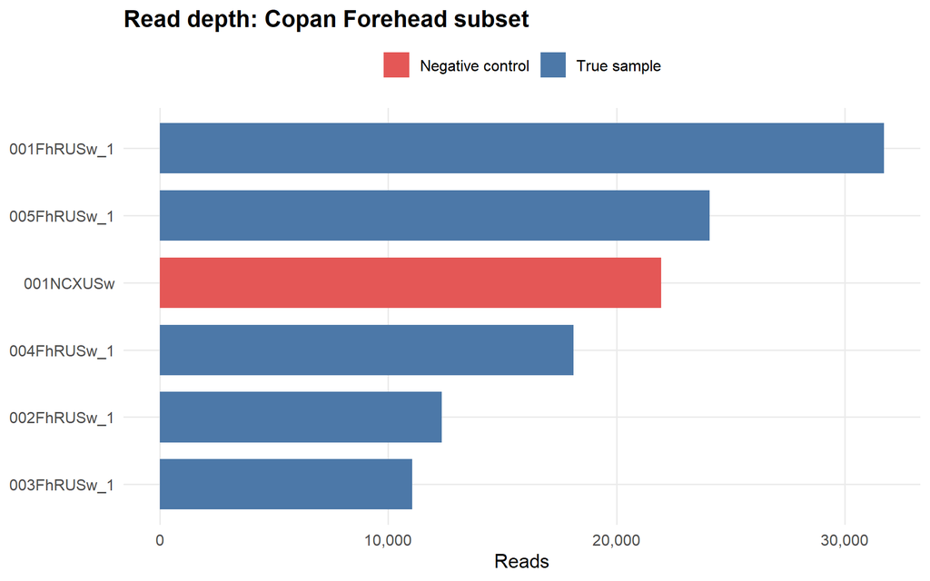

```r
sample_read_plot <- selected_metadata %>%
  mutate(
    phyloseq_sample_id = reorder(phyloseq_sample_id, read_depth)
  ) %>%
  ggplot(aes(x = phyloseq_sample_id, y = read_depth, fill = sample_class)) +
  geom_col(width = 0.75) +
  coord_flip() +
  scale_fill_manual(
    values = c("True sample" = "#4C78A8", "Negative control" = "#E45756")
  ) +
  scale_y_continuous(labels = comma) +
  labs(
    title = "Read depth: Copan Forehead subset",
    x = NULL,
    y = "Reads",
    fill = NULL
  )

sample_read_plot
```

## 5.2 4.2 p score의 순위와 기본 threshold

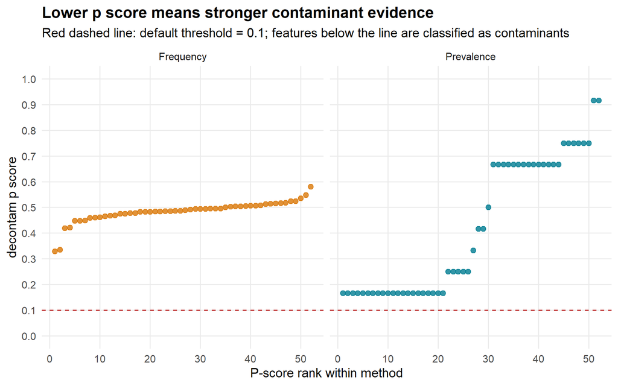

```r
score_rank_data <- score_long %>%
  filter(!is.na(p_score)) %>%
  group_by(method) %>%
  arrange(p_score, .by_group = TRUE) %>%
  mutate(score_rank = row_number()) %>%
  ungroup()

p_score_plot <- ggplot(
  score_rank_data,
  aes(x = score_rank, y = p_score, color = method)
) +
  geom_hline(
    yintercept = default_threshold,
    linetype = "dashed",
    color = "#B91C1C"
  ) +
  geom_point(size = 2, alpha = 0.8) +
  facet_wrap(~method, scales = "free_x") +
  scale_color_manual(values = method_colors) +
  scale_y_continuous(limits = c(0, 1), breaks = seq(0, 1, 0.1)) +
  labs(
    title = "Lower p score means stronger contaminant evidence",
    subtitle = paste0(
      "Red dashed line: default threshold = ",
      default_threshold,
      "; features below the line are classified as contaminants"
    ),
    x = "P-score rank within method",
    y = "decontam p score",
    color = NULL
  ) +
  theme(legend.position = "none")

p_score_plot
```

## 5.3 4.3 Frequency와 Prevalence score 비교

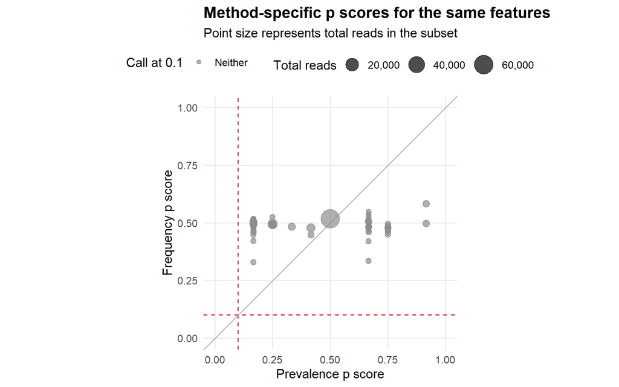

```r
method_comparison_data <- feature_results %>%
  filter(!is.na(p_frequency), !is.na(p_prevalence)) %>%
  mutate(
    default_call = case_when(
      p_frequency < default_threshold &
        p_prevalence < default_threshold ~ "Both",
      p_frequency < default_threshold ~ "Frequency only",
      p_prevalence < default_threshold ~ "Prevalence only",
      TRUE ~ "Neither"
    )
  )

method_comparison_plot <- ggplot(
  method_comparison_data,
  aes(
    x = p_prevalence,
    y = p_frequency,
    size = total_reads,
    color = default_call
  )
) +
  geom_vline(
    xintercept = default_threshold,
    linetype = "dashed",
    color = "#B91C1C"
  ) +
  geom_hline(
    yintercept = default_threshold,
    linetype = "dashed",
    color = "#B91C1C"
  ) +
  geom_abline(slope = 1, intercept = 0, color = "grey70") +
  geom_point(alpha = 0.7) +
  scale_size_continuous(labels = comma, range = c(2, 8)) +
  scale_color_manual(
    values = c(
      "Both" = "#7B2CBF",
      "Frequency only" = "#D97706",
      "Prevalence only" = "#007C91",
      "Neither" = "grey55"
    )
  ) +
  coord_equal(xlim = c(0, 1), ylim = c(0, 1)) +
  labs(
    title = "Method-specific p scores for the same features",
    subtitle = "Point size represents total reads in the subset",
    x = "Prevalence p score",
    y = "Frequency p score",
    size = "Total reads",
    color = paste0("Call at ", default_threshold)
  )

method_comparison_plot
```

## 5.4 4.4 Threshold가 증가할 때 분류 feature 수

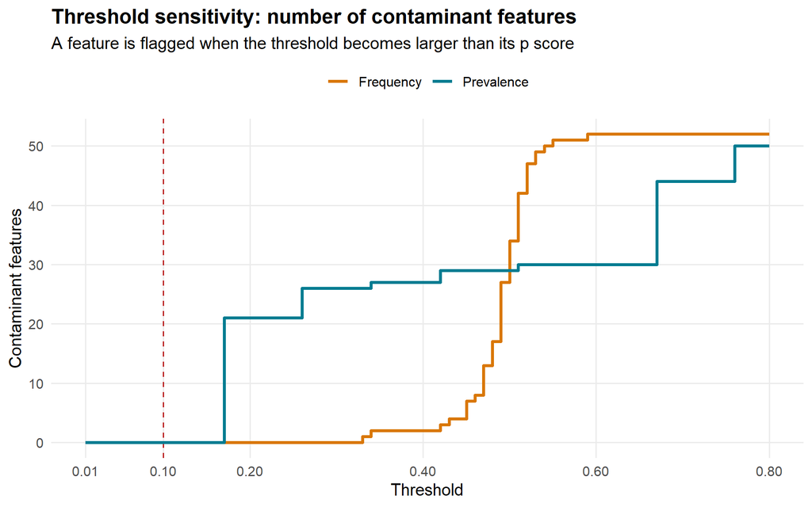

```r
threshold_count_plot <- ggplot(
  sensitivity_summary,
  aes(
    x = threshold,
    y = contaminant_features,
    color = method
  )
) +
  geom_vline(
    xintercept = default_threshold,
    linetype = "dashed",
    color = "#B91C1C"
  ) +
  geom_step(linewidth = 1, direction = "hv") +
  scale_color_manual(values = method_colors) +
  scale_x_continuous(
    breaks = c(0.01, 0.10, 0.20, 0.40, 0.60, 0.80)
  ) +
  scale_y_continuous(labels = comma) +
  labs(
    title = "Threshold sensitivity: number of contaminant features",
    subtitle = "A feature is flagged when the threshold becomes larger than its p score",
    x = "Threshold",
    y = "Contaminant features",
    color = NULL
  )

threshold_count_plot
```

## 5.5 4.5 분류 feature를 제거할 때의 read 영향

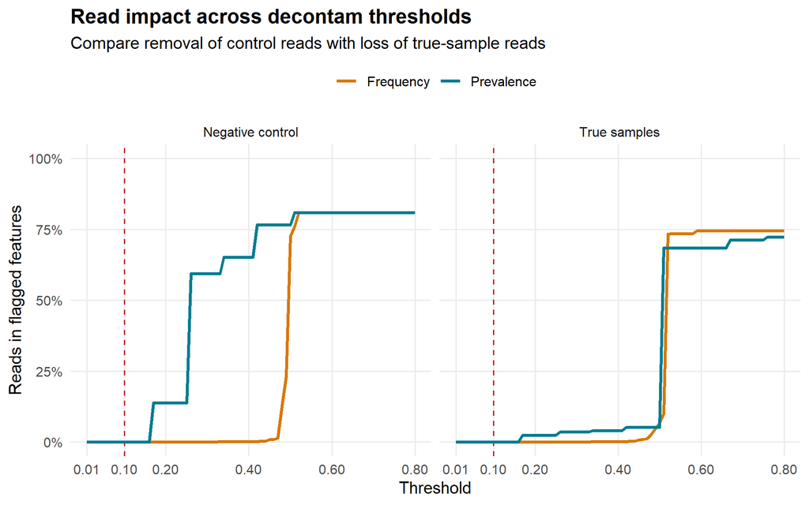

```r
read_impact_data <- sensitivity_summary %>%
  select(
    method,
    threshold,
    true_sample_reads_flagged_pct,
    control_reads_flagged_pct
  ) %>%
  pivot_longer(
    cols = c(
      true_sample_reads_flagged_pct,
      control_reads_flagged_pct
    ),
    names_to = "sample_class",
    values_to = "reads_flagged_pct"
  ) %>%
  mutate(
    sample_class = recode(
      sample_class,
      true_sample_reads_flagged_pct = "True samples",
      control_reads_flagged_pct = "Negative control"
    )
  )

read_impact_plot <- ggplot(
  read_impact_data,
  aes(
    x = threshold,
    y = reads_flagged_pct,
    color = method
  )
) +
  geom_vline(
    xintercept = default_threshold,
    linetype = "dashed",
    color = "#B91C1C"
  ) +
  geom_line(linewidth = 1) +
  facet_wrap(~sample_class) +
  scale_color_manual(values = method_colors) +
  scale_x_continuous(
    breaks = c(0.01, 0.10, 0.20, 0.40, 0.60, 0.80)
  ) +
  scale_y_continuous(
    limits = c(0, 100),
    labels = label_percent(scale = 1)
  ) +
  labs(
    title = "Read impact across decontam thresholds",
    subtitle = "Compare removal of control reads with loss of true-sample reads",
    x = "Threshold",
    y = "Reads in flagged features",
    color = NULL
  )

read_impact_plot
```

## 5.6 4.6 Frequency 방법: 대표 ASV 3개의 DNA 농도–상대빈도

기본 threshold 0.1에서 frequency contaminant로 분류된 ASV는 0개다. 따라서 “기본 기준에서 검출된 대표 3개”를 선택할 수는 없다. 아래에서는 threshold sensitivity를 설명하기 위해 **교육용 완화 threshold 0.5**를 적용했을 때 검출되는 ASV 중 p score가 가장 낮은 3개를 보여준다. 이 선택은 최종 제거 기준을 의미하지 않는다.

```r
frequency_example_features <- feature_results %>%
  filter(
    !is.na(p_frequency),
    p_frequency < illustration_threshold
  ) %>%
  arrange(p_frequency, desc(total_reads)) %>%
  slice_head(n = 3) %>%
  mutate(
    short_feature_id = substr(feature_id, 1, 8),
    facet_label = paste0(
      taxon_label,
      "\nASV ", short_feature_id,
      "; p = ", sprintf("%.3f", p_frequency)
    )
  )

frequency_example_features %>%
  select(
    feature_id,
    taxon_label,
    p_frequency,
    total_reads,
    true_sample_reads,
    control_reads
  ) %>%
  kable(
    caption = paste0(
      "Frequency 그림에 사용한 ASV 3개 (threshold = ",
      illustration_threshold,
      ")"
    ),
    digits = 4,
    format.args = list(big.mark = ",")
  )
```

Frequency 그림에 사용한 ASV 3개 (threshold = 0.5)

| feature_id | taxon_label | p_frequency | total_reads | true_sample_reads | control_reads |
| --- | --- | --- | --- | --- | --- |
| aeea6b40db276dd7ca8b48feb8496324 | Thermus_g | 0.3287 | 82 | 44 | 38 |
| e352ef2edd5a7c02ebf93ed1a2794986 | Corynebacterium_g | 0.3347 | 83 | 83 | 0 |
| 996a85f5800dfb9aaf2dcdf11be163c2 | Corynebacterium_g | 0.4190 | 58 | 58 | 0 |

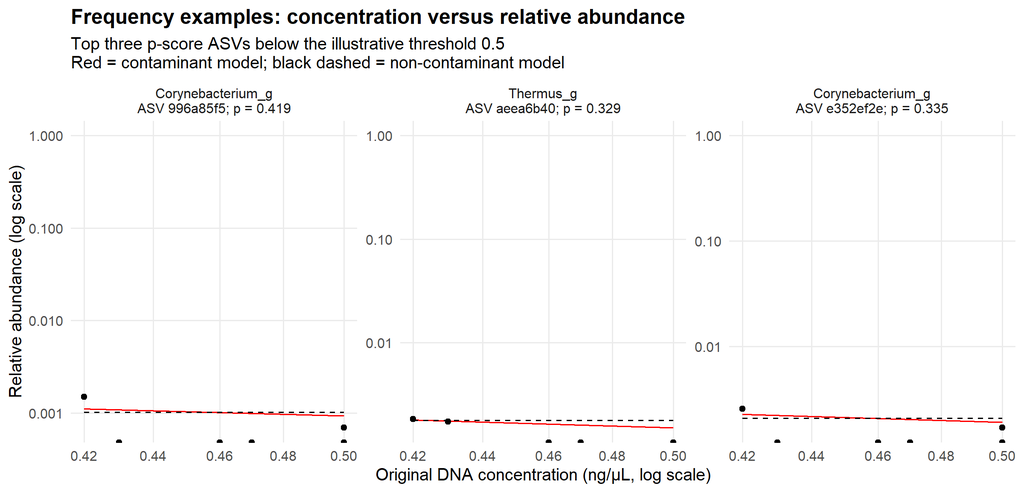

```r
frequency_example_ids <- frequency_example_features$feature_id

frequency_facet_labels <- frequency_example_features$facet_label
names(frequency_facet_labels) <- frequency_example_features$feature_id

frequency_example_plot <- plot_frequency(
  phy_copan_forehead,
  taxa = frequency_example_ids,
  conc = dna_concentration,
  normalize = TRUE,
  showModels = TRUE,
  log = TRUE,
  facet = TRUE
) +
  facet_wrap(
    ~taxa,
    scales = "free_y",
    labeller = as_labeller(frequency_facet_labels)
  ) +
  labs(
    title = "Frequency examples: concentration versus relative abundance",
    subtitle = paste0(
      "Top three p-score ASVs below the illustrative threshold ",
      illustration_threshold,
      "\nRed = contaminant model; black dashed = non-contaminant model"
    ),
    x = "Original DNA concentration (ng/µL, log scale)",
    y = "Relative abundance (log scale)"
  ) +
  theme(legend.position = "none")

frequency_example_plot
```

농도 범위가 0.42–0.50 ng/µL로 좁고, 가장 낮은 frequency p score도 0.329이다. 따라서 점들이 육안으로 뛰렷한 역상관을 보이지 않는 것은 자연스럽다. Frequency p score는 기울기 하나를 눈으로 판독한 값이 아니라, 빨간 역상관 모형과 검은 점선의 농도-무관 모형의 적합을 잔차로 비교한 score다.

## 5.7 4.7 Prevalence 방법: control과 True sample의 검출률 비교

음성대조군이 1개이므로 control prevalence는 0% 또는 100%만 가능하다. 즉, 아래 산점도의 세로축은 정밀한 비율이 아니라 “대조군 1개에서 검출됨/ 검출되지 않음”을 뜻한다. 같은 좌표에 여러 ASV가 겹치므로 점 크기는 해당 조합의 ASV 수를 나타낸다.

```r
prevalence_table_display <- prevalence_comparison %>%
  filter(control_prevalence_n > 0) %>%
  arrange(p_prevalence, desc(control_reads), desc(true_prevalence_n)) %>%
  slice_head(n = 20) %>%
  select(
    feature_id,
    taxon_label,
    control_prevalence_n,
    true_prevalence_n,
    control_prevalence_pct,
    true_prevalence_pct,
    p_prevalence,
    control_reads,
    true_sample_reads
  )

prevalence_table_display %>%
  kable(
    caption = "Control에서 검출된 ASV의 prevalence 비교 (상위 20개)",
    col.names = c(
      "Feature ID",
      "Taxon",
      "Control n/1",
      "True n/5",
      "Control (%)",
      "True (%)",
      "p score",
      "Control reads",
      "True reads"
    ),
    digits = 3,
    format.args = list(big.mark = ",")
  )
```

Control에서 검출된 ASV의 prevalence 비교 (상위 20개)

| Feature ID | Taxon | Control n/1 | True n/5 | Control (%) | True (%) | p score | Control reads | True reads |
| --- | --- | --- | --- | --- | --- | --- | --- | --- |
| 1ebf82770d39e7dea4cdd6525d634ae2 | Brevundimonas_g | 1 | 1 | 100 | 20 | 0.167 | 1,542 | 28 |
| eafd5ed5949335dcc9571e96a30c242a | Pseudomonas_g | 1 | 1 | 100 | 20 | 0.167 | 277 | 26 |
| dc48fa77e362e32c1c0cd76272dddec9 | Sphingomonas_g | 1 | 1 | 100 | 20 | 0.167 | 236 | 58 |
| 09fa7968bafe83eb2e527701f26035de | Sphingomonadaceae_f | 1 | 1 | 100 | 20 | 0.167 | 173 | 9 |
| 19efac48457c44e44de9dee0a284c57e | Acinetobacter_g | 1 | 1 | 100 | 20 | 0.167 | 136 | 24 |
| 89f92a98c085f073bc78411e3801a85d | Enhydrobacter_g | 1 | 1 | 100 | 20 | 0.167 | 93 | 22 |
| b94a8e609e84f35c93506768aac4ec3f | Acetobacter_g | 1 | 1 | 100 | 20 | 0.167 | 88 | 40 |
| e81d19fdebac3afb7580eb6b34bc313b | Roseomonas_g | 1 | 1 | 100 | 20 | 0.167 | 72 | 13 |
| 44a942b69a980b0f71708f39677e0fab | Saccharimonadaceae_g | 1 | 1 | 100 | 20 | 0.167 | 61 | 110 |
| 0f257eb6554772452f4dd12919b5ea5c | Sphingomonadaceae_f | 1 | 1 | 100 | 20 | 0.167 | 53 | 37 |
| 6f715e2799d9b2427abf0eece1ffc7d3 | Staphylococcus_g | 1 | 1 | 100 | 20 | 0.167 | 51 | 100 |
| bbd9195eb175dbfe0bbe51314886d77c | Staphylococcus_g | 1 | 1 | 100 | 20 | 0.167 | 41 | 50 |
| aeea6b40db276dd7ca8b48feb8496324 | Thermus_g | 1 | 1 | 100 | 20 | 0.167 | 38 | 44 |
| 1cbda894755e11f49abb45473b87fa68 | Enhydrobacter_g | 1 | 1 | 100 | 20 | 0.167 | 36 | 12 |
| daaaef75203e565e99ae0771a9444f21 | Acetobacter_g | 1 | 1 | 100 | 20 | 0.167 | 34 | 18 |
| 022314bfa98b2d5c22f3cc3b59a300c5 | Novosphingobium_g | 1 | 1 | 100 | 20 | 0.167 | 27 | 19 |
| 0d223446a6bb0a4f2b01838ac7764ceb | Thermus_g | 1 | 1 | 100 | 20 | 0.167 | 21 | 14 |
| 5c6bf470e7d8fb12db69d5da4616a9a8 | Massilia_g | 1 | 1 | 100 | 20 | 0.167 | 21 | 42 |
| 597c178a32c8e105554890ac672203a1 | Lactococcus_g | 1 | 1 | 100 | 20 | 0.167 | 13 | 1,676 |
| 83df293667c11dd7ccebd05bb943a3f4 | Sphingomonas_g | 1 | 1 | 100 | 20 | 0.167 | 10 | 4 |

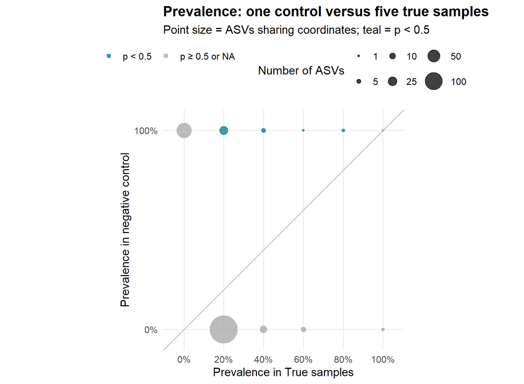

```r
prevalence_plot_data <- prevalence_comparison %>%
  mutate(
    sensitivity_call = if_else(
      !is.na(p_prevalence) & p_prevalence < illustration_threshold,
      paste0("p < ", illustration_threshold),
      paste0("p ≥ ", illustration_threshold, " or NA")
    )
  )

prevalence_comparison_plot <- ggplot(
  prevalence_plot_data,
  aes(
    x = true_prevalence_pct,
    y = control_prevalence_pct,
    color = sensitivity_call
  )
) +
  geom_abline(slope = 1, intercept = 0, color = "grey75") +
  geom_count(alpha = 0.75) +
  scale_color_manual(
    values = setNames(
      c("#007C91", "grey65"),
      c(
        paste0("p < ", illustration_threshold),
        paste0("p ≥ ", illustration_threshold, " or NA")
      )
    )
  ) +
  scale_size_area(max_size = 13, breaks = c(1, 5, 10, 25, 50, 100)) +
  scale_x_continuous(
    limits = c(-5, 105),
    breaks = seq(0, 100, 20),
    labels = label_percent(scale = 1)
  ) +
  scale_y_continuous(
    limits = c(-5, 105),
    breaks = c(0, 100),
    labels = label_percent(scale = 1)
  ) +
  coord_equal() +
  labs(
    title = "Prevalence: one control versus five true samples",
    subtitle = paste0(
      "Point size = ASVs sharing coordinates; teal = p < ",
      illustration_threshold
    ),
    x = "Prevalence in True samples",
    y = "Prevalence in negative control",
    color = NULL,
    size = "Number of ASVs"
  )

prevalence_comparison_plot
```

# 6 5. 결과 저장

```r
results_dir <- "results/decontam_copan_forehead"
dir.create(results_dir, recursive = TRUE, showWarnings = FALSE)

save_figure <- function(plot_object, file_name, width, height) {
  ggsave(
    filename = file.path(results_dir, file_name),
    plot = plot_object,
    device = grDevices::png,
    type = "cairo",
    width = width,
    height = height,
    units = "in",
    dpi = 300,
    bg = "white"
  )
}

save_figure(sample_read_plot, "01_sample_read_depth.png", 7, 4.5)
save_figure(p_score_plot, "02_p_score_rank.png", 8, 4.8)
save_figure(method_comparison_plot, "03_method_comparison.png", 7, 6)
save_figure(threshold_count_plot, "04_threshold_sensitivity.png", 8, 5)
save_figure(read_impact_plot, "05_read_impact.png", 9, 4.8)
save_figure(frequency_example_plot, "06_frequency_top3_examples.png", 10, 4.8)
save_figure(
  prevalence_comparison_plot,
  "07_prevalence_control_vs_true.png",
  7.5,
  5.5
)

write.csv(
  selected_metadata,
  file.path(results_dir, "selected_samples.csv"),
  row.names = FALSE,
  fileEncoding = "UTF-8"
)

write.csv(
  feature_results,
  file.path(results_dir, "feature_level_decontam_scores.csv"),
  row.names = FALSE,
  na = "",
  fileEncoding = "UTF-8"
)

write.csv(
  sensitivity_summary,
  file.path(results_dir, "threshold_sensitivity_summary.csv"),
  row.names = FALSE,
  fileEncoding = "UTF-8"
)

write.csv(
  frequency_example_features,
  file.path(results_dir, "frequency_top3_example_features.csv"),
  row.names = FALSE,
  na = "",
  fileEncoding = "UTF-8"
)

write.csv(
  prevalence_comparison,
  file.path(results_dir, "prevalence_control_vs_true_all_features.csv"),
  row.names = FALSE,
  na = "",
  fileEncoding = "UTF-8"
)

saveRDS(
  phy_copan_forehead,
  file.path(results_dir, "phy_copan_forehead_5_true_1_control.rds")
)

writeLines(
  capture.output(sessionInfo()),
  file.path(results_dir, "session_info.txt")
)
```

# 7 6. 해석 가이드

1. `p_score`가 작을수록 해당 방법이 관찰한 contaminant 패턴이 강하다.
2. 분류식은 `p_score < threshold`이며, threshold 자체가 p score인 것은 아니다.
3. threshold를 올리면 contaminant로 부르는 feature 수가 단조롭게 증가한다.
4. Frequency와 Prevalence는 서로 다른 정보를 사용하므로 동일한 feature에 다른 score를 줄 수 있다.
5. `p_score = NA`는 “깨끗함”이 아니라 이 subset에서 평가 정보가 부족함을 뜻한다.
6. 대조군 1개에서는 prevalence p score가 세밀하게 변하지 않고 가능한 값이 제한된다. 따라서 실제 제거 기준은 전체 대조군을 함께 사용한 분석에서 결정하는 편이 안전하다.
7. Threshold 선택은 contaminant feature 수만 보지 말고, control에서 제거되는 read 비율과 True sample에서 함께 손실되는 read 비율을 같이 비교한다.
8. Frequency 대표 3개는 threshold 0.50에서의 민감도 설명용이며, 기본 threshold 0.10에서 검출된 contaminant가 아니다.
9. Control 1개로 계산한 prevalence는 이산적이고 불안정하므로, 실제 제거 기준은 전체 control을 사용한 분석에서 다시 확인한다.